# Project Description

This project involves the exploration and analysis of HR data obtained from XYZ Technologies. The dataset encompasses critical employee information, including identifiers, designations, performance scores, and salary details.

As a Data Scientist, the goal is to utilize data visualization tools such as seaborn and matplotlib to create informative charts.

## Importing Modules for the Task

```python
import pandas as pd
import numpy as np
import seaborn as sns
sns.set_theme()
import matplotlib.pyplot as plt
import datetime
```

Data Extraction, Transformation, Loading and Analyses

```python
import pandas as pd
df =pd.read_csv('HRDataset_v14 .csv')
```

```python
df
```

|  | Employee_Name | EmpID | MarriedID | MaritalStatusID | GenderID | EmpStatusID | DeptID | PerfScoreID | FromDiversityJobFairID | Salary | ... | ManagerName | ManagerID | RecruitmentSource | PerformanceScore | EngagementSurvey | EmpSatisfaction | SpecialProjectsCount | LastPerformanceReview_Date | DaysLateLast30 | Absences |
| --- | --- | --- | --- | --- | --- | --- | --- | --- | --- | --- | --- | --- | --- | --- | --- | --- | --- | --- | --- | --- | --- |
| 0 | Adinolfi, Wilson K | 10026 | 0 | 0 | 1 | 1 | 5 | 4 | 0 | 62506 | ... | Michael Albert | 22.0 | LinkedIn | Exceeds | 4.60 | 5 | 0 | 1/17/2019 | 0 | 1 |
| 1 | Ait Sidi, Karthikeyan | 10084 | 1 | 1 | 1 | 5 | 3 | 3 | 0 | 104437 | ... | Simon Roup | 4.0 | Indeed | Fully Meets | 4.96 | 3 | 6 | 2/24/2016 | 0 | 17 |
| 2 | Akinkuolie, Sarah | 10196 | 1 | 1 | 0 | 5 | 5 | 3 | 0 | 64955 | ... | Kissy Sullivan | 20.0 | LinkedIn | Fully Meets | 3.02 | 3 | 0 | 5/15/2012 | 0 | 3 |
| 3 | Alagbe,Trina | 10088 | 1 | 1 | 0 | 1 | 5 | 3 | 0 | 64991 | ... | Elijiah Gray | 16.0 | Indeed | Fully Meets | 4.84 | 5 | 0 | 01/03/2019 | 0 | 15 |
| 4 | Anderson, Carol | 10069 | 0 | 2 | 0 | 5 | 5 | 3 | 0 | 50825 | ... | Webster Butler | 39.0 | Google Search | Fully Meets | 5.00 | 4 | 0 | 02/01/2016 | 0 | 2 |
| ... | ... | ... | ... | ... | ... | ... | ... | ... | ... | ... | ... | ... | ... | ... | ... | ... | ... | ... | ... | ... | ... |
| 306 | Woodson, Jason | 10135 | 0 | 0 | 1 | 1 | 5 | 3 | 0 | 65893 | ... | Kissy Sullivan | 20.0 | LinkedIn | Fully Meets | 4.07 | 4 | 0 | 2/28/2019 | 0 | 13 |
| 307 | Ybarra, Catherine | 10301 | 0 | 0 | 0 | 5 | 5 | 1 | 0 | 48513 | ... | Brannon Miller | 12.0 | Google Search | PIP | 3.20 | 2 | 0 | 09/02/2015 | 5 | 4 |
| 308 | Zamora, Jennifer | 10010 | 0 | 0 | 0 | 1 | 3 | 4 | 0 | 220450 | ... | Janet King | 2.0 | Employee Referral | Exceeds | 4.60 | 5 | 6 | 2/21/2019 | 0 | 16 |
| 309 | Zhou, Julia | 10043 | 0 | 0 | 0 | 1 | 3 | 3 | 0 | 89292 | ... | Simon Roup | 4.0 | Employee Referral | Fully Meets | 5.00 | 3 | 5 | 02/01/2019 | 0 | 11 |
| 310 | Zima, Colleen | 10271 | 0 | 4 | 0 | 1 | 5 | 3 | 0 | 45046 | ... | David Stanley | 14.0 | LinkedIn | Fully Meets | 4.50 | 5 | 0 | 1/30/2019 | 0 | 2 |

311 rows × 35 columns

```python
df.head(10)
```

|  | Employee_Name | EmpID | MarriedID | MaritalStatusID | GenderID | EmpStatusID | DeptID | PerfScoreID | FromDiversityJobFairID | Salary | ... | ManagerName | ManagerID | RecruitmentSource | PerformanceScore | EngagementSurvey | EmpSatisfaction | SpecialProjectsCount | LastPerformanceReview_Date | DaysLateLast30 | Absences |
| --- | --- | --- | --- | --- | --- | --- | --- | --- | --- | --- | --- | --- | --- | --- | --- | --- | --- | --- | --- | --- | --- |
| 0 | Adinolfi, Wilson K | 10026 | 0 | 0 | 1 | 1 | 5 | 4 | 0 | 62506 | ... | Michael Albert | 22.0 | LinkedIn | Exceeds | 4.60 | 5 | 0 | 1/17/2019 | 0 | 1 |
| 1 | Ait Sidi, Karthikeyan | 10084 | 1 | 1 | 1 | 5 | 3 | 3 | 0 | 104437 | ... | Simon Roup | 4.0 | Indeed | Fully Meets | 4.96 | 3 | 6 | 2/24/2016 | 0 | 17 |
| 2 | Akinkuolie, Sarah | 10196 | 1 | 1 | 0 | 5 | 5 | 3 | 0 | 64955 | ... | Kissy Sullivan | 20.0 | LinkedIn | Fully Meets | 3.02 | 3 | 0 | 5/15/2012 | 0 | 3 |
| 3 | Alagbe,Trina | 10088 | 1 | 1 | 0 | 1 | 5 | 3 | 0 | 64991 | ... | Elijiah Gray | 16.0 | Indeed | Fully Meets | 4.84 | 5 | 0 | 01/03/2019 | 0 | 15 |
| 4 | Anderson, Carol | 10069 | 0 | 2 | 0 | 5 | 5 | 3 | 0 | 50825 | ... | Webster Butler | 39.0 | Google Search | Fully Meets | 5.00 | 4 | 0 | 02/01/2016 | 0 | 2 |
| 5 | Anderson, Linda | 10002 | 0 | 0 | 0 | 1 | 5 | 4 | 0 | 57568 | ... | Amy Dunn | 11.0 | LinkedIn | Exceeds | 5.00 | 5 | 0 | 01/07/2019 | 0 | 15 |
| 6 | Andreola, Colby | 10194 | 0 | 0 | 0 | 1 | 4 | 3 | 0 | 95660 | ... | Alex Sweetwater | 10.0 | LinkedIn | Fully Meets | 3.04 | 3 | 4 | 01/02/2019 | 0 | 19 |
| 7 | Athwal, Sam | 10062 | 0 | 4 | 1 | 1 | 5 | 3 | 0 | 59365 | ... | Ketsia Liebig | 19.0 | Employee Referral | Fully Meets | 5.00 | 4 | 0 | 2/25/2019 | 0 | 19 |
| 8 | Bachiochi, Linda | 10114 | 0 | 0 | 0 | 3 | 5 | 3 | 1 | 47837 | ... | Brannon Miller | 12.0 | Diversity Job Fair | Fully Meets | 4.46 | 3 | 0 | 1/25/2019 | 0 | 4 |
| 9 | Bacong, Alejandro | 10250 | 0 | 2 | 1 | 1 | 3 | 3 | 0 | 50178 | ... | Peter Monroe | 7.0 | Indeed | Fully Meets | 5.00 | 5 | 6 | 2/18/2019 | 0 | 16 |

10 rows × 35 columns

```python
#Checking the column information of the data frame
df.info()
```

```
<class 'pandas.core.frame.DataFrame'>
RangeIndex: 311 entries, 0 to 310
Data columns (total 35 columns):
 #   Column                      Non-Null Count  Dtype
---  ------                      --------------  -----
 0   Employee_Name               311 non-null    object
 1   EmpID                       311 non-null    int64
 2   MarriedID                   311 non-null    int64
 3   MaritalStatusID             311 non-null    int64
 4   GenderID                    311 non-null    int64
 5   EmpStatusID                 311 non-null    int64
 6   DeptID                      311 non-null    int64
 7   PerfScoreID                 311 non-null    int64
 8   FromDiversityJobFairID      311 non-null    int64
 9   Salary                      311 non-null    int64
```

[output cut: 27 more lines]

```python
#Having the ststaistical analysis of the given data frame.
df.describe()
```

|  | EmpID | MarriedID | MaritalStatusID | GenderID | EmpStatusID | DeptID | PerfScoreID | FromDiversityJobFairID | Salary | Termd | PositionID | Zip | ManagerID | EngagementSurvey | EmpSatisfaction | SpecialProjectsCount | DaysLateLast30 | Absences |
| --- | --- | --- | --- | --- | --- | --- | --- | --- | --- | --- | --- | --- | --- | --- | --- | --- | --- | --- |
| count | 311.000000 | 311.000000 | 311.000000 | 311.000000 | 311.000000 | 311.000000 | 311.000000 | 311.000000 | 311.000000 | 311.000000 | 311.000000 | 311.000000 | 303.000000 | 311.000000 | 311.000000 | 311.000000 | 311.000000 | 311.000000 |
| mean | 10156.000000 | 0.398714 | 0.810289 | 0.434084 | 2.392283 | 4.610932 | 2.977492 | 0.093248 | 69020.684887 | 0.334405 | 16.845659 | 6555.482315 | 14.570957 | 4.110000 | 3.890675 | 1.218650 | 0.414791 | 10.237942 |
| std | 89.922189 | 0.490423 | 0.943239 | 0.496435 | 1.794383 | 1.083487 | 0.587072 | 0.291248 | 25156.636930 | 0.472542 | 6.223419 | 16908.396884 | 8.078306 | 0.789938 | 0.909241 | 2.349421 | 1.294519 | 5.852596 |
| min | 10001.000000 | 0.000000 | 0.000000 | 0.000000 | 1.000000 | 1.000000 | 1.000000 | 0.000000 | 45046.000000 | 0.000000 | 1.000000 | 1013.000000 | 1.000000 | 1.120000 | 1.000000 | 0.000000 | 0.000000 | 1.000000 |
| 25% | 10078.500000 | 0.000000 | 0.000000 | 0.000000 | 1.000000 | 5.000000 | 3.000000 | 0.000000 | 55501.500000 | 0.000000 | 18.000000 | 1901.500000 | 10.000000 | 3.690000 | 3.000000 | 0.000000 | 0.000000 | 5.000000 |
| 50% | 10156.000000 | 0.000000 | 1.000000 | 0.000000 | 1.000000 | 5.000000 | 3.000000 | 0.000000 | 62810.000000 | 0.000000 | 19.000000 | 2132.000000 | 15.000000 | 4.280000 | 4.000000 | 0.000000 | 0.000000 | 10.000000 |
| 75% | 10233.500000 | 1.000000 | 1.000000 | 1.000000 | 5.000000 | 5.000000 | 3.000000 | 0.000000 | 72036.000000 | 1.000000 | 20.000000 | 2355.000000 | 19.000000 | 4.700000 | 5.000000 | 0.000000 | 0.000000 | 15.000000 |
| max | 10311.000000 | 1.000000 | 4.000000 | 1.000000 | 5.000000 | 6.000000 | 4.000000 | 1.000000 | 250000.000000 | 1.000000 | 30.000000 | 98052.000000 | 39.000000 | 5.000000 | 5.000000 | 8.000000 | 6.000000 | 20.000000 |

```python
#Checking the shape of the data
df.shape
```

```
(311, 35)
```

```python
df[['Employee_Name','GenderID']].head(10)
```

|  | Employee_Name | GenderID |
| --- | --- | --- |
| 0 | Adinolfi, Wilson K | 1 |
| 1 | Ait Sidi, Karthikeyan | 1 |
| 2 | Akinkuolie, Sarah | 0 |
| 3 | Alagbe,Trina | 0 |
| 4 | Anderson, Carol | 0 |
| 5 | Anderson, Linda | 0 |
| 6 | Andreola, Colby | 0 |
| 7 | Athwal, Sam | 1 |
| 8 | Bachiochi, Linda | 0 |
| 9 | Bacong, Alejandro | 1 |

From the data we can conclude that the female gender is represented as 0 and the male gender as 1.

```python
df[['Employee_Name','Position','PositionID']].head(10)
```

|  | Employee_Name | Position | PositionID |
| --- | --- | --- | --- |
| 0 | Adinolfi, Wilson K | Production Technician I | 19 |
| 1 | Ait Sidi, Karthikeyan | Sr. DBA | 27 |
| 2 | Akinkuolie, Sarah | Production Technician II | 20 |
| 3 | Alagbe,Trina | Production Technician I | 19 |
| 4 | Anderson, Carol | Production Technician I | 19 |
| 5 | Anderson, Linda | Production Technician I | 19 |
| 6 | Andreola, Colby | Software Engineer | 24 |
| 7 | Athwal, Sam | Production Technician I | 19 |
| 8 | Bachiochi, Linda | Production Technician I | 19 |
| 9 | Bacong, Alejandro | IT Support | 14 |

```python
df[['Employee_Name','EmploymentStatus']].head(10)
```

|  | Employee_Name | EmploymentStatus |
| --- | --- | --- |
| 0 | Adinolfi, Wilson K | Active |
| 1 | Ait Sidi, Karthikeyan | Voluntarily Terminated |
| 2 | Akinkuolie, Sarah | Voluntarily Terminated |
| 3 | Alagbe,Trina | Active |
| 4 | Anderson, Carol | Voluntarily Terminated |
| 5 | Anderson, Linda | Active |
| 6 | Andreola, Colby | Active |
| 7 | Athwal, Sam | Active |
| 8 | Bachiochi, Linda | Active |
| 9 | Bacong, Alejandro | Active |

```python
df[['Employee_Name','Position','PositionID']].head(10)
```

|  | Employee_Name | Position | PositionID |
| --- | --- | --- | --- |
| 0 | Adinolfi, Wilson K | Production Technician I | 19 |
| 1 | Ait Sidi, Karthikeyan | Sr. DBA | 27 |
| 2 | Akinkuolie, Sarah | Production Technician II | 20 |
| 3 | Alagbe,Trina | Production Technician I | 19 |
| 4 | Anderson, Carol | Production Technician I | 19 |
| 5 | Anderson, Linda | Production Technician I | 19 |
| 6 | Andreola, Colby | Software Engineer | 24 |
| 7 | Athwal, Sam | Production Technician I | 19 |
| 8 | Bachiochi, Linda | Production Technician I | 19 |
| 9 | Bacong, Alejandro | IT Support | 14 |

```python
df[['Employee_Name','Absences']].head(10)
```

|  | Employee_Name | Absences |
| --- | --- | --- |
| 0 | Adinolfi, Wilson K | 1 |
| 1 | Ait Sidi, Karthikeyan | 17 |
| 2 | Akinkuolie, Sarah | 3 |
| 3 | Alagbe,Trina | 15 |
| 4 | Anderson, Carol | 2 |
| 5 | Anderson, Linda | 15 |
| 6 | Andreola, Colby | 19 |
| 7 | Athwal, Sam | 19 |
| 8 | Bachiochi, Linda | 4 |
| 9 | Bacong, Alejandro | 16 |

```python
df[['Employee_Name','TermReason']].head(10)
```

|  | Employee_Name | TermReason |
| --- | --- | --- |
| 0 | Adinolfi, Wilson K | N/A-StillEmployed |
| 1 | Ait Sidi, Karthikeyan | career change |
| 2 | Akinkuolie, Sarah | hours |
| 3 | Alagbe,Trina | N/A-StillEmployed |
| 4 | Anderson, Carol | return to school |
| 5 | Anderson, Linda | N/A-StillEmployed |
| 6 | Andreola, Colby | N/A-StillEmployed |
| 7 | Athwal, Sam | N/A-StillEmployed |
| 8 | Bachiochi, Linda | N/A-StillEmployed |
| 9 | Bacong, Alejandro | N/A-StillEmployed |

```python
df[['Employee_Name','PerformanceScore']].head(10)
```

|  | Employee_Name | PerformanceScore |
| --- | --- | --- |
| 0 | Adinolfi, Wilson K | Exceeds |
| 1 | Ait Sidi, Karthikeyan | Fully Meets |
| 2 | Akinkuolie, Sarah | Fully Meets |
| 3 | Alagbe,Trina | Fully Meets |
| 4 | Anderson, Carol | Fully Meets |
| 5 | Anderson, Linda | Exceeds |
| 6 | Andreola, Colby | Fully Meets |
| 7 | Athwal, Sam | Fully Meets |
| 8 | Bachiochi, Linda | Fully Meets |
| 9 | Bacong, Alejandro | Fully Meets |

```python
df[['Employee_Name','MaritalDesc']].head(10)
```

|  | Employee_Name | MaritalDesc |
| --- | --- | --- |
| 0 | Adinolfi, Wilson K | Single |
| 1 | Ait Sidi, Karthikeyan | Married |
| 2 | Akinkuolie, Sarah | Married |
| 3 | Alagbe,Trina | Married |
| 4 | Anderson, Carol | Divorced |
| 5 | Anderson, Linda | Single |
| 6 | Andreola, Colby | Single |
| 7 | Athwal, Sam | Widowed |
| 8 | Bachiochi, Linda | Single |
| 9 | Bacong, Alejandro | Divorced |

```python
df[['Employee_Name','Sex']].head(10)
```

|  | Employee_Name | Sex |
| --- | --- | --- |
| 0 | Adinolfi, Wilson K | M |
| 1 | Ait Sidi, Karthikeyan | M |
| 2 | Akinkuolie, Sarah | F |
| 3 | Alagbe,Trina | F |
| 4 | Anderson, Carol | F |
| 5 | Anderson, Linda | F |
| 6 | Andreola, Colby | F |
| 7 | Athwal, Sam | M |
| 8 | Bachiochi, Linda | F |
| 9 | Bacong, Alejandro | M |

```python
df[['Employee_Name','MarriedID','MaritalStatusID','MaritalDesc']].head(10)
```

|  | Employee_Name | MarriedID | MaritalStatusID | MaritalDesc |
| --- | --- | --- | --- | --- |
| 0 | Adinolfi, Wilson K | 0 | 0 | Single |
| 1 | Ait Sidi, Karthikeyan | 1 | 1 | Married |
| 2 | Akinkuolie, Sarah | 1 | 1 | Married |
| 3 | Alagbe,Trina | 1 | 1 | Married |
| 4 | Anderson, Carol | 0 | 2 | Divorced |
| 5 | Anderson, Linda | 0 | 0 | Single |
| 6 | Andreola, Colby | 0 | 0 | Single |
| 7 | Athwal, Sam | 0 | 4 | Widowed |
| 8 | Bachiochi, Linda | 0 | 0 | Single |
| 9 | Bacong, Alejandro | 0 | 2 | Divorced |

```python
df[['Employee_Name','CitizenDesc']].head(10)
```

|  | Employee_Name | CitizenDesc |
| --- | --- | --- |
| 0 | Adinolfi, Wilson K | US Citizen |
| 1 | Ait Sidi, Karthikeyan | US Citizen |
| 2 | Akinkuolie, Sarah | US Citizen |
| 3 | Alagbe,Trina | US Citizen |
| 4 | Anderson, Carol | US Citizen |
| 5 | Anderson, Linda | US Citizen |
| 6 | Andreola, Colby | US Citizen |
| 7 | Athwal, Sam | US Citizen |
| 8 | Bachiochi, Linda | US Citizen |
| 9 | Bacong, Alejandro | US Citizen |

```python
df[['Employee_Name','Salary','SpecialProjectsCount','Position']].head(10)
```

|  | Employee_Name | Salary | SpecialProjectsCount | Position |
| --- | --- | --- | --- | --- |
| 0 | Adinolfi, Wilson K | 62506 | 0 | Production Technician I |
| 1 | Ait Sidi, Karthikeyan | 104437 | 6 | Sr. DBA |
| 2 | Akinkuolie, Sarah | 64955 | 0 | Production Technician II |
| 3 | Alagbe,Trina | 64991 | 0 | Production Technician I |
| 4 | Anderson, Carol | 50825 | 0 | Production Technician I |
| 5 | Anderson, Linda | 57568 | 0 | Production Technician I |
| 6 | Andreola, Colby | 95660 | 4 | Software Engineer |
| 7 | Athwal, Sam | 59365 | 0 | Production Technician I |
| 8 | Bachiochi, Linda | 47837 | 0 | Production Technician I |
| 9 | Bacong, Alejandro | 50178 | 6 | IT Support |

Now we can visualize the graphs and charts

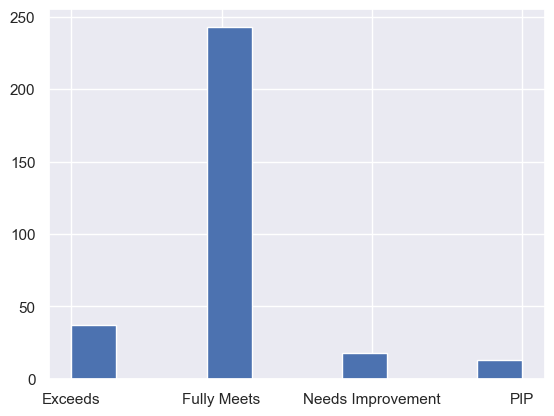

```python
df['PerformanceScore'].hist()
```

From the histogram, we can conclude that the majority of performance score in 'Fully Meets' category.

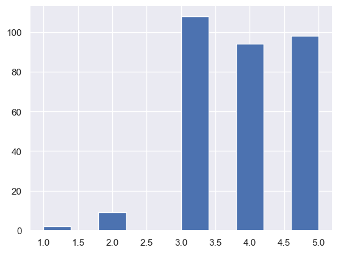

```python
df['EmpSatisfaction'].hist()
```

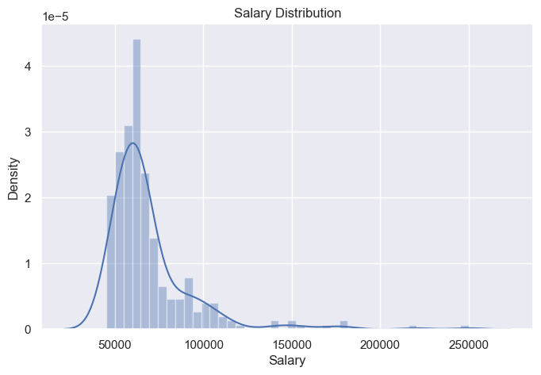

```python
#Histogram of the major continuous columns  salary
fig = plt.figure(figsize=(8,5))
g = sns.distplot(df.Salary)
g.set_title('Salary Distribution');
```

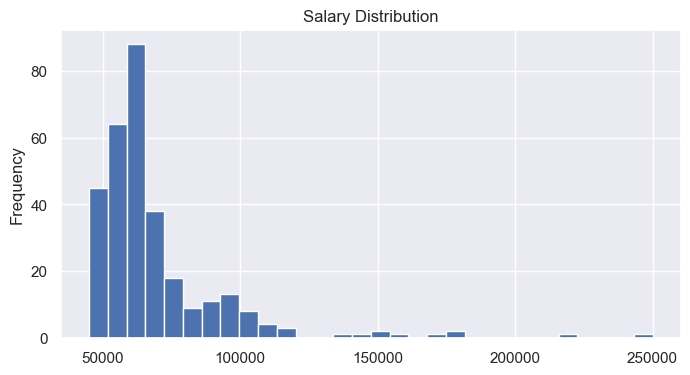

```python
figscale = 1
df['Salary'].plot(kind='hist', bins=30, title='Salary Distribution', figsize=(8*figscale, 4*figscale))
```

The salary distirbution is skewed, with the high majority of employees who is having the salary between 50,000 to 100,000.

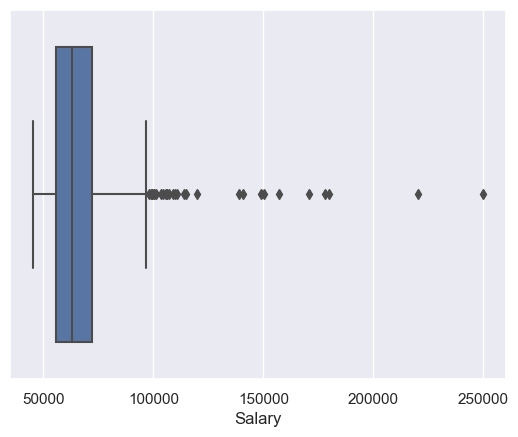

```python
sns.boxplot(data = df, x='Salary')
```

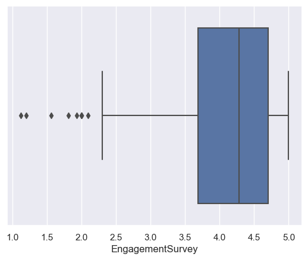

```python
sns.boxplot(data = df, x='EngagementSurvey')
```

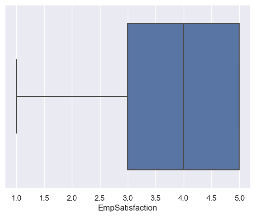

```python
sns.boxplot(data = df, x='EmpSatisfaction')
```

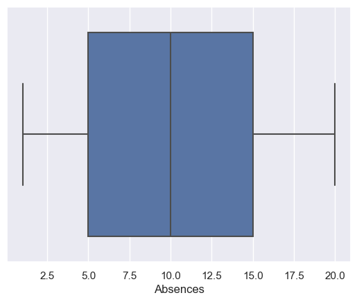

```python
sns.boxplot(data = df, x='Absences')
```

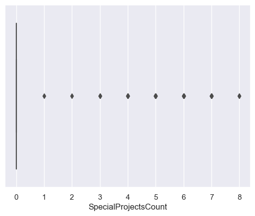

```python
sns.boxplot(data = df, x='SpecialProjectsCount')
```

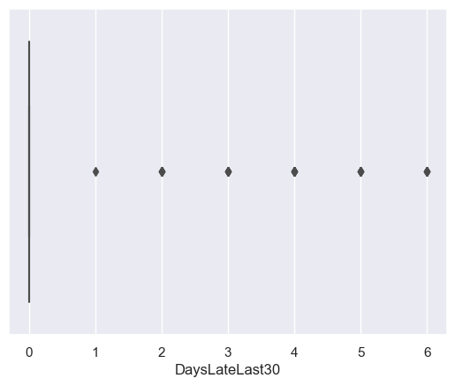

```python
sns.boxplot(data = df, x='DaysLateLast30')
```

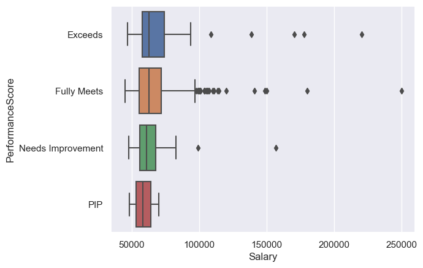

```python
sns.boxplot(data = df, x='Salary', y="PerformanceScore")
```

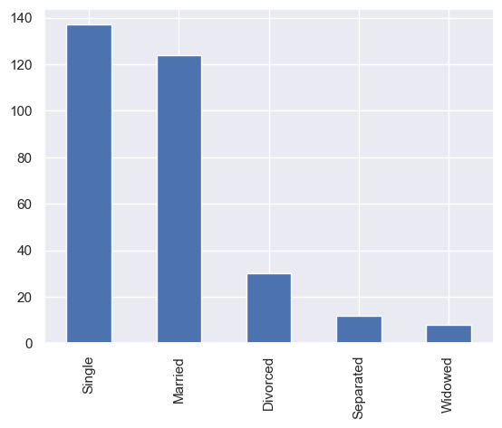

```python
df['MaritalDesc'].value_counts().plot(kind='bar')
```

It seems like majority of employees are single or married but how many of them are still active ?

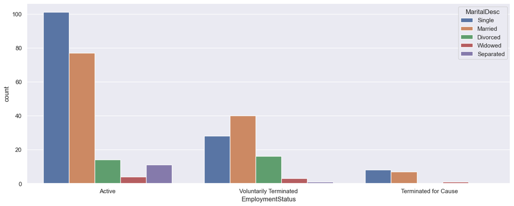

```python
plt.figure(figsize=(16, 6))
sns.countplot(x=df['EmploymentStatus'], hue=df['MaritalDesc'])
```

From the figure the majority of employees are single and actively working. Most people who were divorced or widowed are not active. Minority of married people left voluntarily, perhaps because of a change of company or region.

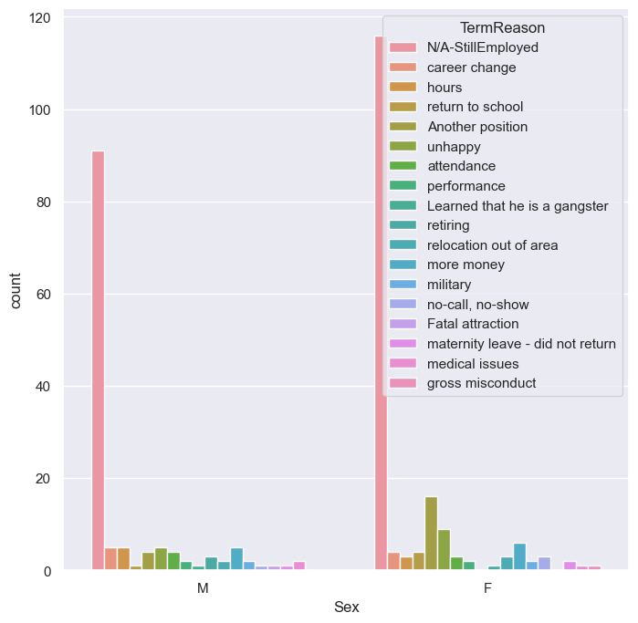

```python
plt.figure(figsize=(8, 8))
sns.countplot(x=df['Sex'], hue=df['TermReason'])
```

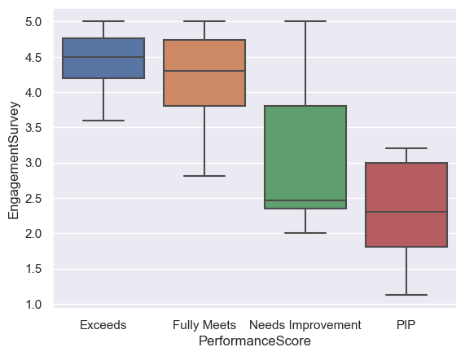

```python
sns.boxplot(data=df, x="PerformanceScore", y="EngagementSurvey")
```

Also the performance was measured by engagement survey,and the corralation is linear.

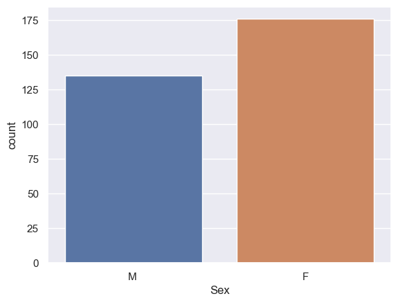

```python
sns.countplot(data=df, x='Sex')
```

Based on the graph, the company shows welcoming diversity in terms of gender. However, the graph only depicts two gender identities.

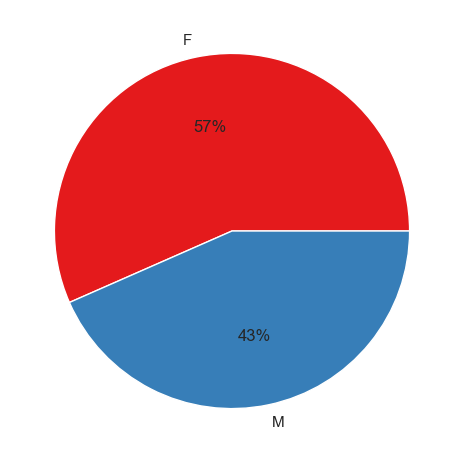

```python
#pie chart

h = pd.DataFrame(df["Sex"].value_counts()).reset_index()
palette_color = sns.color_palette('bright')
plt.pie(h["Sex"], labels=h["index"], colors=sns.color_palette('Set1'),autopct='%.0f%%')
plt.tight_layout()
```

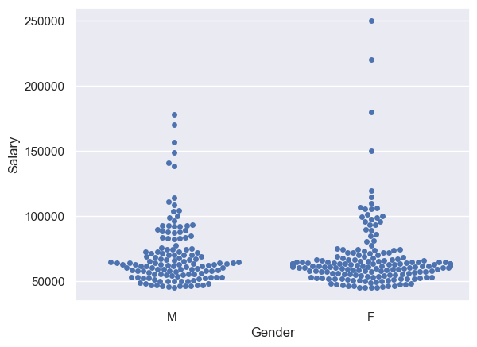

```python
sns.swarmplot(x='Sex', y='Salary', data=df)
plt.xlabel("Gender")
plt.ylabel("Salary")
```

Again for gender based analysis from above there are few number of female with Salary higher than 2,00,000, which is also a good sign for equal pay and diversity.

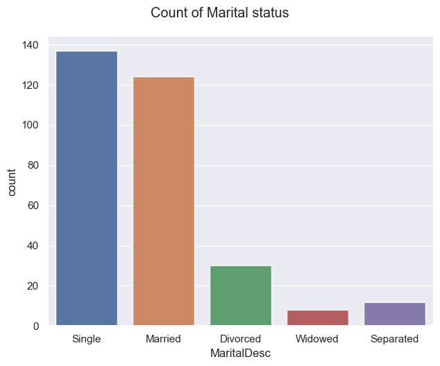

```python
# Checking marital status of the employees
fig = plt.figure(figsize=(8,5))
g = sns.catplot(x="MaritalDesc",kind='count',order=['Single', 'Married', 'Divorced', 'Widowed', 'Separated'], aspect=1.3, data=df);
g.fig.suptitle("Count of Marital status",y=1.05)
```

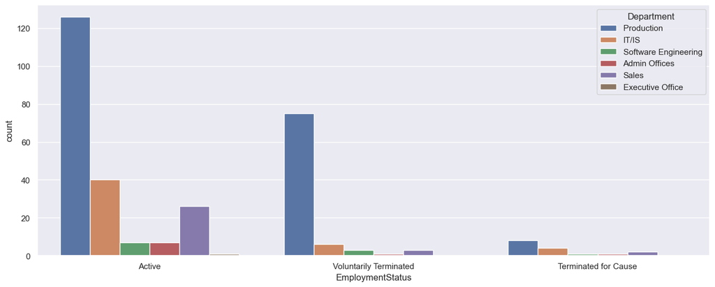

```python
plt.figure(figsize=(16, 6))
sns.countplot(x=df['EmploymentStatus'], hue=df['Department'])
```

In all types of employment relationships, the production department has the most employees.

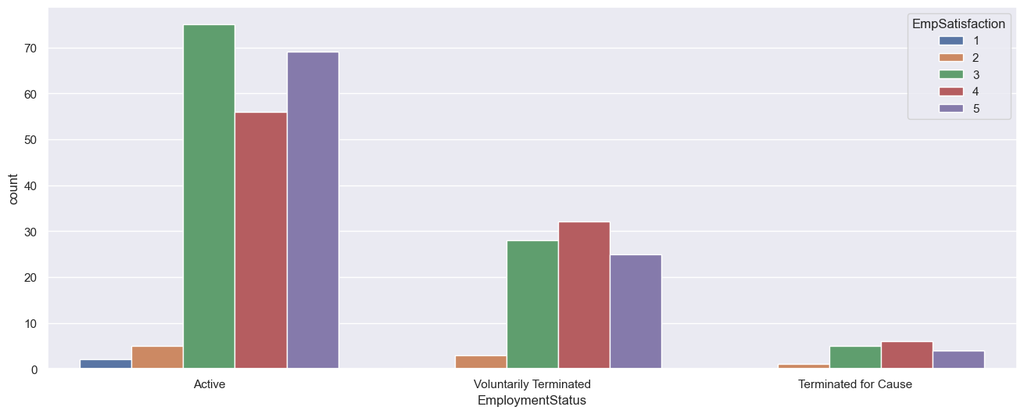

```python
plt.figure(figsize=(16, 6))
sns.countplot(x=df['EmploymentStatus'], hue=df['EmpSatisfaction'])
```

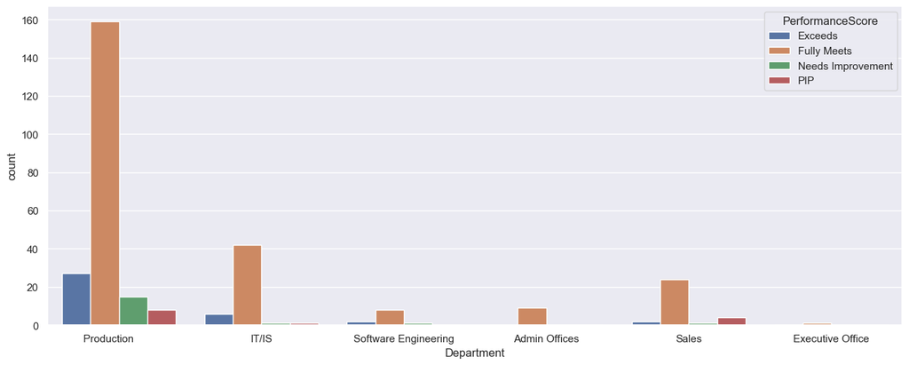

```python
plt.figure(figsize=(16, 6))
sns.countplot(x=df['Department'], hue=df['PerformanceScore'])
```

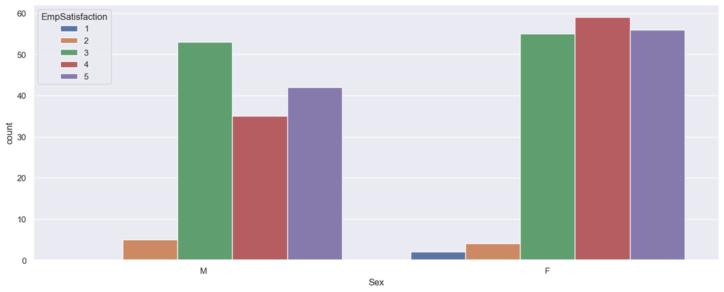

```python
plt.figure(figsize=(16, 6))
sns.countplot(x=df['Sex'], hue=df['EmpSatisfaction'])
```

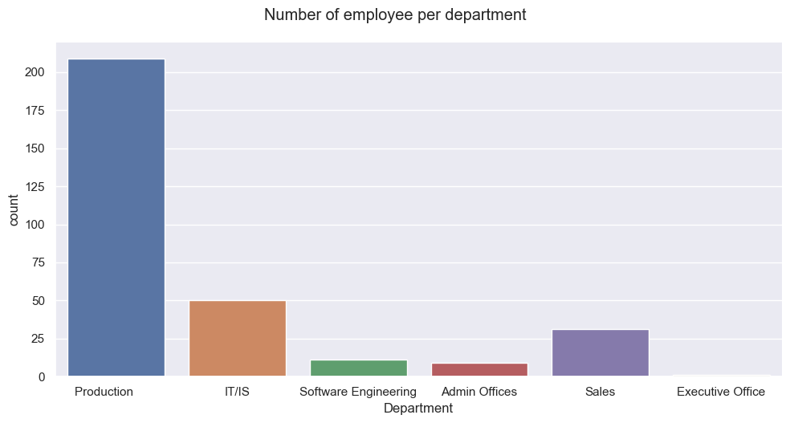

```python
# The number of the staff regarding the department
fig = plt.figure(figsize=(10,4))
g = sns.catplot(x="Department",kind='count',order=['Production       ', 'IT/IS', 'Software Engineering',
       'Admin Offices', 'Sales', 'Executive Office'], aspect=2.0, data=df);
g.fig.suptitle("Number of employee per department",y=1.05);
```

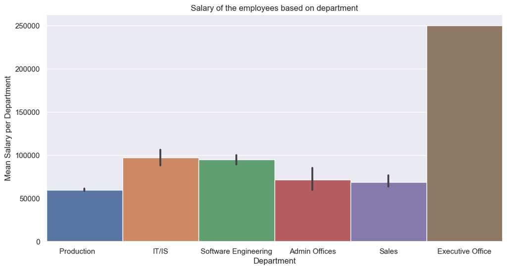

```python
# Mean Salary per department
plt.figure(figsize=(12, 6))
sns.barplot(x='Department', y='Salary', width = 1.0, data=df)
plt.title('Salary of the employees based on department')
plt.xlabel('Department')
plt.ylabel('Mean Salary per Department')
plt.show()
```

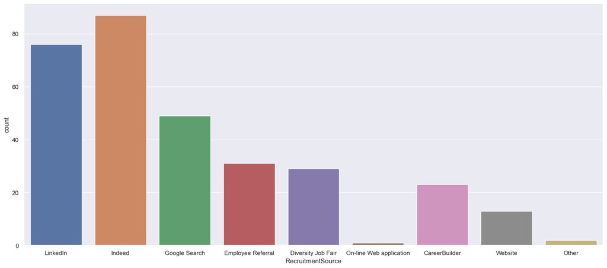

```python
#Hiring platforms preffered
plt.figure(figsize = (19, 8))

sns.countplot( x ="RecruitmentSource", data=df)
```

Indeed,LinkedIn and Goodle Search is the top three recruitment source among all.

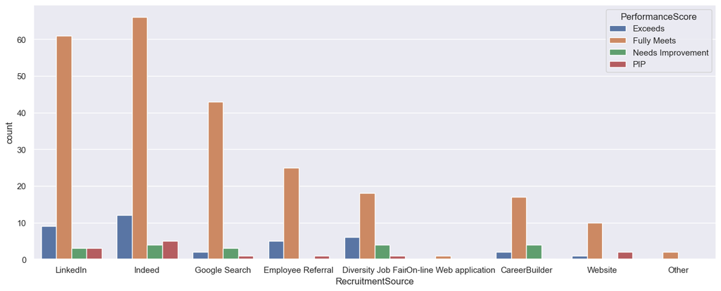

```python
plt.figure(figsize=(16, 6))
sns.countplot(x=df['RecruitmentSource'], hue=df['PerformanceScore'])
```

Employee performance is correlated with the recruitment source's popularity. This illustrates that the right places to find passionate and enthusiastic individuals are the sources.

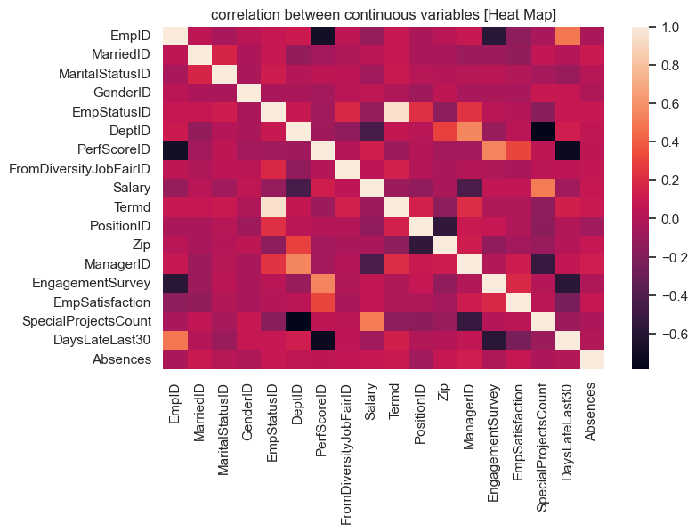

```python
#heat map
fig = plt.figure(figsize=(8,5))
g = sns.heatmap(df.corr());
g.set_title('correlation between continuous variables [Heat Map]')
```